# Results

Tim Ballesteros

2025-02-23

## Methodology

To test whether an algorithm randomly constructing congressional districts within the typical confines - contiguous, equal populations - I use Ohio as an example. Using the post-2010 United States Census redistricting, population data from 2010 is used in conjunction with Ohio’s 2020 election results, which use districts based on the 2010 Census.

## Findings

### Partisanship

Using the Sainte-Lague formula for calculating multi-member district proportional representation, the 2020 Ohio election results give an expected seat allocation of 9 seats to Republicans and 7 seats to Democrats based on presidential election results, and 9 seats to Republicans and 7 seats to Democrats based on congressional election results. The actual seat allocation of Ohio’s 16 congressional seats in 2020 was 12 Republican-elected districts and 4 Democrat-elected districts.

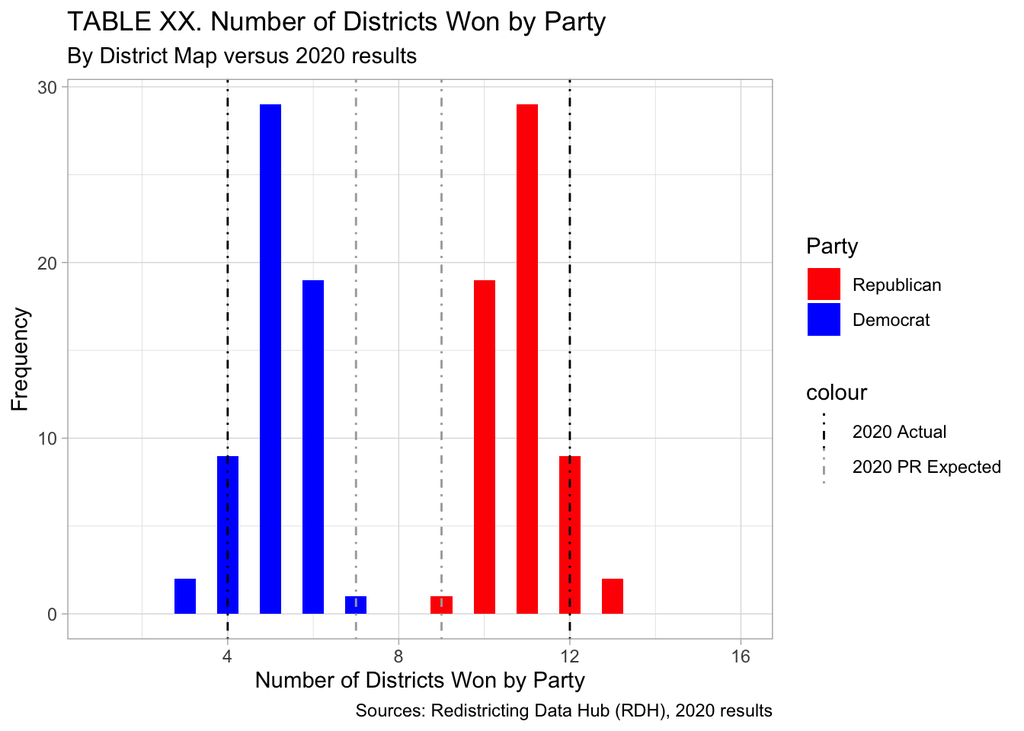

The random algorithm on average produced a seat distribution of 11 Republican to 5 Democrat seats, which is closer to the expected proportional representation than the actual results.

### Population

Congressional districts within each state are required to have equal populations, though the degree of their margin of error varies by state. Ultimately, districts will have small deviations above or below the target amount due to compiling geographic units of various populations. Ohio’s Constitution, as updated in 2021, stipulates that “[i]n no event shall any district contain a population of less than ninety-five per cent nor more than one hundred five per cent of the applicable ratio of representation” (Article XI, Section 3(B)(1)).[^1] This allows districts to have a population range of 10% of the target district population, which based on the 2010 Census would be 72,103 individuals.

For Ohio’s redrawing following the 2010 Census, each district was expected to have approximately 721,032 individuals across its now 16 congressional districts. Using the same Census data, Ohio’s districts in the 113th Congress ranged from 698,259 individuals (96.78% of the target population) to 738,859 individuals (102.4%).

[figure not shown]

### Race

States are forbidden from use race or ethnicity to politically disadvantage one or more particular groups. However, several states require the creation of one or more majority-minority districts, that is, a district with a larger proportion of non-White individuals (Hispanic White individuals included) than White, non-Hispanic individuals. With the strong (though decreasing) correlation between race/ethnicity and voting patterns, separating redistricting based on demographic and partisan characteristics is challenging.

Due to data availability, ethnicity is not included in this analysis. Based on the 2010 Census, Ohio’s Hispanic population was 354,674, or 3.1% of the state’s population. Out of this, 180,174 individuals, or just over half (50.8%) of Ohio’s Hispanic population, identified as White alone, accounting for 1.56% of Ohio’s total population. Due to the exclusion of Hispanic data, this analysis’s results will show slightly elevated numbers of White individuals and slightly lowered numbers of non-White individuals.

Overall, Ohio’s population according to the 2010 Census was 82.70% White, 12.24% Black, 1.74% Asian, 0.19% American Indian or Alaskan Native (AIAN), 0.04% Native Hawaiian or Pacific Islander (NHPI), 0.79% other race, and 2.30% individuals identifying as two or more races. The proportion of non-White individuals in Ohio is 17.30%.

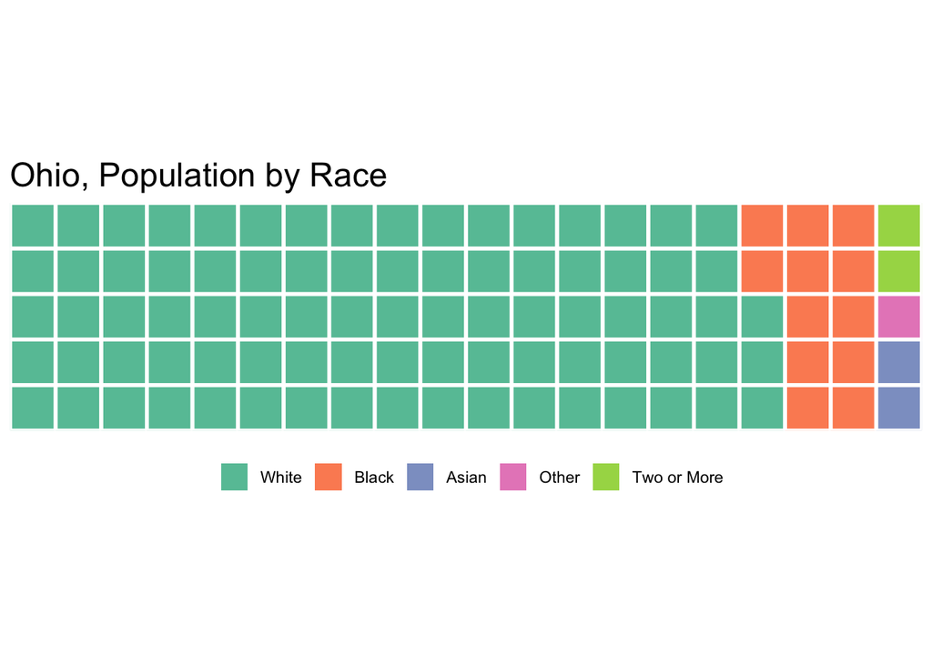

[^1]: Ohio Constitution Article XI, Section 3: https://codes.ohio.gov/ohio-constitution/section-11.3